# OHBM Educational Course 2022 - Re-executing a publication

In this R notebook, you will be able to make plots for looking through some of the data that will be used to calculate case/control effect sizes and evaluate descriptive statistics for your cohort along the way.

First, you need to make sure to set all the appropriate parameters.

We will plot age distributions for diagnostic and sex differences for each cohort, but you can use this setup for other plots as well.

The first part of this notebook is set up just as before. You will need to install some R packages and load the libraries to ensure plots are displayed.

### Read in the data and set the output folder and file names!

```r
datafile <- read.csv("all4sites_data_OHBM.csv"); #Read in the file
#datafile <- read.csv("metr_SubCortical_OHBM.csv"); #Read in the file
#datafile <- read.csv("OpenNeuro_results.csv"); #Read in the file

## REMEMBER TO CHANGE THE OUTPUT NAME EACH RUN
outFolder="./AllDATA_allROIs_woICV/" ; dir.create(outFolder,"/",showWarnings = FALSE);
cohortName="MyOHBMcohort-AllDATAFull-woICV"
eName="ENIGMA-PD"
```

```r
# Double check the column names of the file you read in:
columnnames = colnames(datafile);
colnames(datafile)
```

```
##  [1] "SubjID"           "Dx"               "Sex"              "Age"
##  [5] "site"             "cohort"           "DURILL"           "AO"
##  [9] "HY1234"           "Hoehn_Yahr_stage" "ICV"              "LLatVent"
## [13] "RLatVent"         "Lthal"            "Rthal"            "Lcaud"
## [17] "Rcaud"            "Lput"             "Rput"             "Lpal"
## [21] "Rpal"             "Lhippo"           "Rhippo"           "Lamyg"
## [25] "Ramyg"            "Laccumb"          "Raccumb"
```

Do you need to calculate ICV?

```r
   if (length(datafile[,which(columnnames=="ICV")]) == 0
       && length(datafile[,which(columnnames=="csf..mm.3.")]) > 0 ) {
     print("It looks like you are working with the OHBM results and ICV is not included. We will add volumes of CSF, gray and white matter for you here -- this will serve as a proxy for ICV.")
     ICV=datafile$csf..mm.3. + datafile$white..mm.3. + datafile$gray..mm.3.
     ncol=dim(datafile)[2] ;
     datafile[,ncol+1]=ICV ; colnames(datafile) <- c(columnnames,"ICV"); columnnames = colnames(datafile) }
```

### This code is exclusively for case/control effect sizes as described by the Cohen’s D statistic. It is important to ensure the code uses the proper column and indicator for cases vs controls:

```r
# what is the column header for case/control or indicating diagnostic status?
caseColumnHeader= "Dx" #"Dx"
# how are cases coded (1,0,"patients","cases")?
caseIndicator=1 # in this code those not coded as cases are assumed to be controls
```

### We will be including age and sex in all models here. However, you can turn this feature off.

```r
# what is the column header for age?
ageColumnHeader="Age" # "Age"
# what is the column header for sex?
sexColumnHeader="Sex" # "Sex"
# how are males coded (1,0,"M","males",-0.5)?
maleIndicator=1 #sex is included in the regression as a categorical variable, or factor
# would you like to include age, sex, and an age-x-sex interaction term in the regression?
includeAgeSexinModel=TRUE
# includeAgeSexInteractioninModel == TRUE # this option has been removed but you can add it back in (experts only -- be careful!)
```

### Do you have other covariates to include? We will ask about continuous and categorical variables separately

#### First, continuous:

```r
# how many continuous covariates other than age should be used from your spreadsheet?
otherCovariatesN=0
# list out the covariates and separate them with a semi-colon
otherCovariates="ICV"
#note if your ROI is ICV, you will not want ICV as a covariate, so you'd have to run through the script again for the separate model
```

#### Next, categorical:

```r
# how many categorical covariates are in your spreadsheet other than sex?
## (examples might include site / scanner / study / different diagnostic groups)
otherCatCovariatesN=0
# list out the categorical covariates (coded as factors) and separate them with a semi-colon
otherCatCovariates="site"
```

### What ROIs will you be looping over with the same statistical model?

```r
#ROINames<-c("Left-Accumbens-area (mm^3)","Left-Amygdala (mm^3)","Left-Caudate (mm^3)","Left-Hippocampus (mm^3)","Left-Pallidum (mm^3)","Left-Putamen (mm^3)","Left-Thalamus-Proper (mm^3)","Right-Accumbens-area (mm^3)","Right-Amygdala (mm^3)","Right-Caudate (mm^3)","Right-Hippocampus (mm^3)","Right-Pallidum (mm^3)","Right-Putamen (mm^3)","Right-Thalamus-Proper (mm^3)");

ROINames<-c("Lthal","Rthal","Lcaud","Rcaud","Lput","Rput","Lpal","Rpal","Lhippo","Rhippo","Lamyg","Ramyg","Laccumb","Raccumb")

# ICV would require a different model since we will covary for ICV for the subcortical regions, so we'd run that separately
#ROINames<-c("ICV")
ROINames<-make.names(ROINames)
#Get number of structures to test
Nrois=length(ROINames)
print(paste("We will be looping Cohen's D statistics over data from",Nrois,"regions of interest."))
```

```
## [1] "We will be looping Cohen's D statistics over data from 14 regions of interest."
```

### We will source some functions that we will use for Cohen’s D calculations from a linear regression output. Feel free to take a look at these functions to see what they do

```r
# If this file is in the same folder as your current working directory, no need to change the input, otherwise please make sure the file with the appropriate path is sourced.
source('ENIGMA_cohensD_functions.R')
```

# Here we go!

## Sanity checks:

```r
 # Check for duplicated SubjIDs that may cause issues with merging data sets.
 if(anyDuplicated(datafile[,1]) != 0) { stop('You have duplicate SubjIDs in your file or subject ID is not your first column.\nMake sure there are no repeat SubjIDs.') }

 # Check all ROIs are column headers in the input CSV
 missingROIS=NULL; l_missing=0;
 for (roi in 1:Nrois) {
   if (length(datafile[,which(columnnames==ROINames[roi])]) == 0) {
        print(ROINames[roi])
     missingROIS=paste(missingROIS,ROINames[roi])
     l_missing=l_missing+1; }
   }
 if (l_missing >= 1) { warning(paste("You are missing ROIs in your file.\n Please check.",sep=""))}
```

## Group statistics and plots

Make sure packages are installed

```r
install.packages('tidyverse','ggpubr','DT','RColorBrewer','scales')
```

Load libraries

```r
library(ggpubr)
library('tidyverse')
library('DT')
library(scales)
library(RColorBrewer)
```

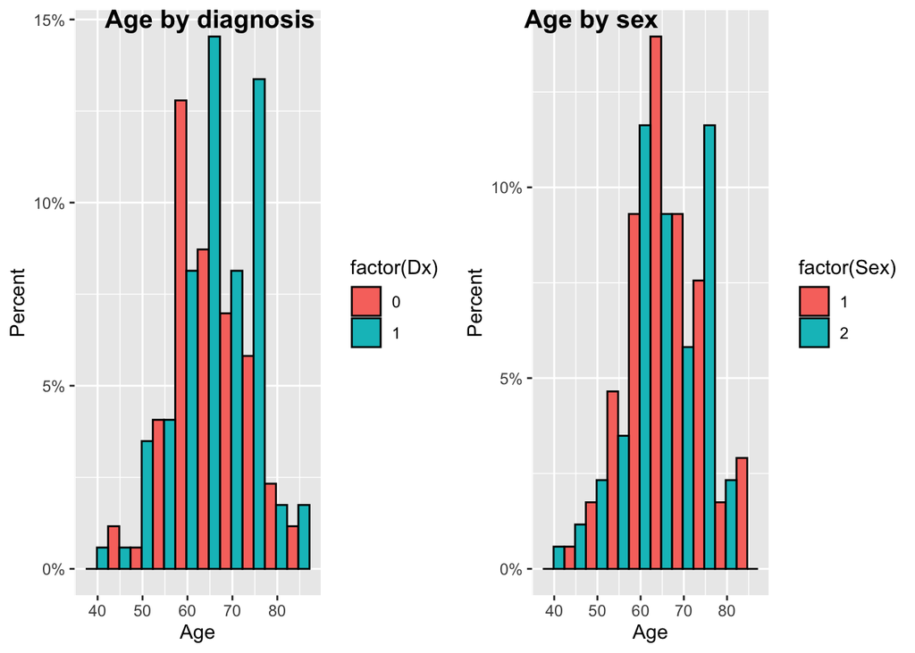

```r
p1<- ggplot(data=datafile, aes(.data[[ageColumnHeader]], fill=factor(.data[[caseColumnHeader]])))  +
  geom_histogram(aes(y = (..count..)/sum(..count..)),bins=10, position = "dodge",color="black"  ) +
        scale_y_continuous(labels = percent) +
   xlab("Age")+ ylab("Percent")
p2<- ggplot(data=datafile, aes(.data[[ageColumnHeader]], fill=factor(.data[[sexColumnHeader]]))) +
   geom_histogram(aes(y = (..count..)/sum(..count..)),bins=10, position = "dodge",color="black" ) +
        scale_y_continuous(labels = percent) +
   xlab("Age")+ ylab("Percent")
ggarrange(p1,p2, labels=c("Age by diagnosis", "Age by sex"),ncol=2,nrow=1,common.legend = FALSE, legend = "right")
```

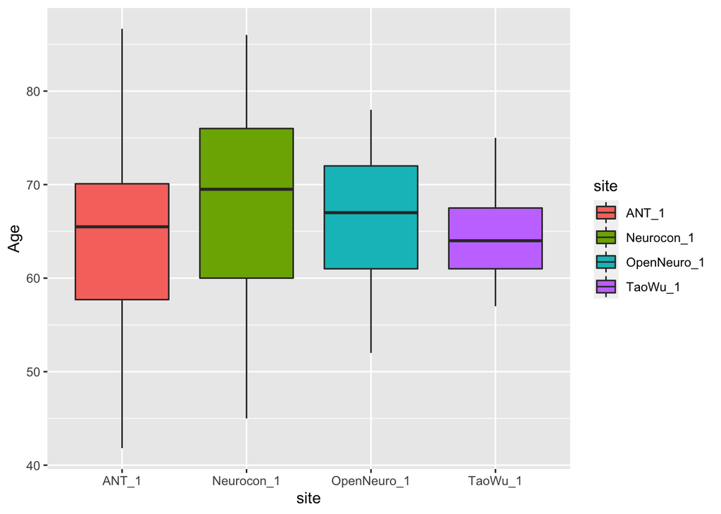

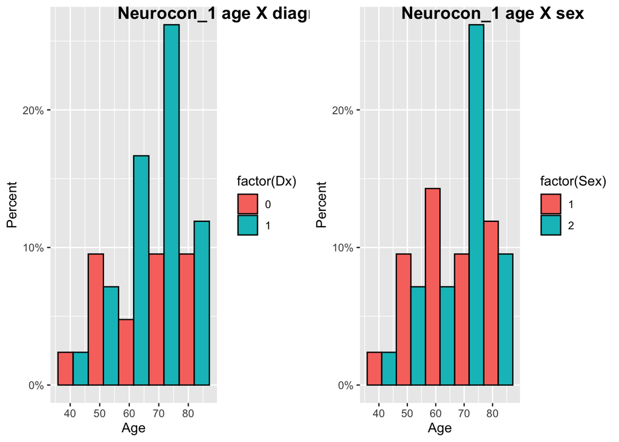

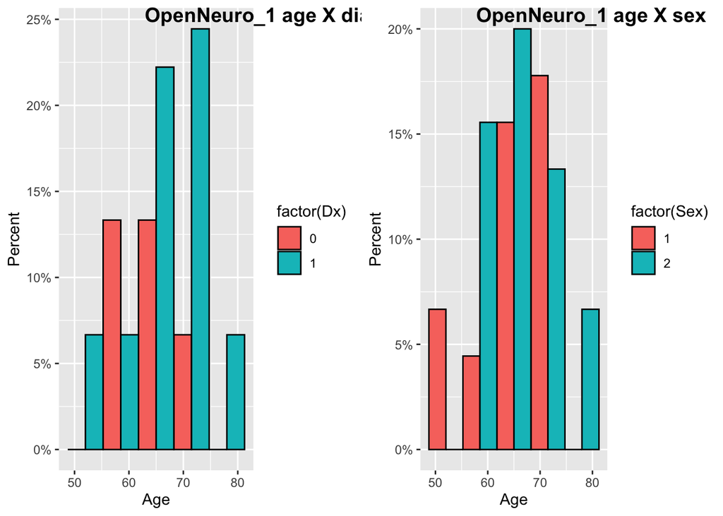

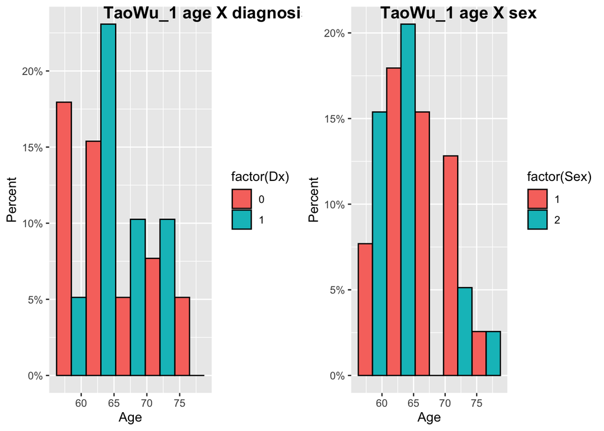

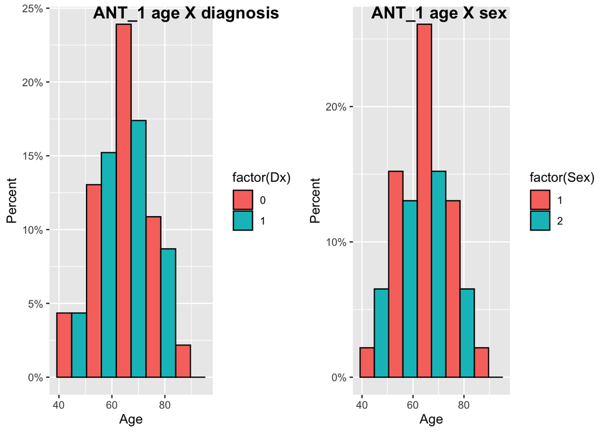

```r
# Box plot for multiple sites
if (length(datafile[,which(columnnames=="site")]) != 0 ) {
  bp<-ggplot(datafile, aes(x=site, y=.data[[ageColumnHeader]], fill=site)) +
  geom_boxplot()
figure<-bp
print(figure)
  for (s in unique(datafile$site)) {
    datasite = subset.data.frame(datafile,site==s)
    p1<- ggplot(data=datasite, aes(.data[[ageColumnHeader]], fill=factor(.data[[caseColumnHeader]])))  +
  geom_histogram(aes(y = (..count..)/sum(..count..)),bins=5, position = "dodge",color="black"  ) +
        scale_y_continuous(labels = percent) +
   xlab("Age")+ ylab("Percent")
p2<- ggplot(data=datasite, aes(.data[[ageColumnHeader]], fill=factor(.data[[sexColumnHeader]]))) +
   geom_histogram(aes(y = (..count..)/sum(..count..)),bins=5, position = "dodge",color="black" ) +
        scale_y_continuous(labels = percent) +
   xlab("Age")+ ylab("Percent")
figure<-ggarrange(p1,p2, labels=c(paste(s,"age X diagnosis"), paste(s,"age X sex")),ncol=2,nrow=1,common.legend = FALSE, legend = "right")
print(figure)
  }
}
```